# List of Questions:

1. Import the spam dataset and print the first six rows.
2. Read through the documentation of the original dataset here:

http://archive.ics.uci.edu/ml/machine-learning-databases/spambase/spambase.names

The dependent variable is "spam" where one indicates that an email is spam and zero otherwise. Which three variables in the dataset do you think will be important predictors in a model of spam? Why?

1. Visualize the univariate distribution of each of the variables in the previous question.
2. Drawing from the full spam dataset, name each of the supervised learning models that we have learned thus far that are used to predict dependent variables like "spam".
3. Describe the importance of training and test data. Why do we separate data into these subsets?
4. What is k-fold cross validation and what do we use it for?
5. How is k-fold cross validation different from stratified k-fold cross validation?
6. Choose one model from question four. Split the data into training and test subsets. Build a model with the three variables in the dataset that you think will be good predictors of "spam". Describe why you chose any particular parameters for your model (e.g.- if you used KNN how did you decide to choose a specific value for k). Run the model and evaluate prediction error in two ways. A) On test data directly and B) using k-fold cross-validation.
7. Choose a second model from question four. Using the same three variables in the dataset that you think will be good predictors of "spam". Describe why you chose any particular parameters for your model (e.g.- if you used KNN how did you decide to choose a specific value for k). Run the model and evaluate prediction error in two ways. A) On test data directly and B) using k-fold cross-validation. Did this model predict test data better than your previous model?
8. Choose a third model from question four. Using the same three variables in the dataset that you think will be good predictors of "spam". Describe why you chose any particular parameters for your model (e.g.- if you used KNN how did you decide to choose a specific value for k). Run the model and evaluate prediction error in two ways. A) On test data directly and B) using k-fold cross-validation. Did this model predict test data better than your previous models?
9. Choose a fourth model from question four. Using the same three variables in the dataset that you think will be good predictors of "spam". Describe why you chose any particular parameters for your model (e.g.- if you used KNN how did you decide to choose a specific value for k). Run the model and evaluate prediction error in two ways. A) On test data directly and B) using k-fold cross-validation. Did this model predict test data better than your previous models?
10. Now rerun your best model from questions 8 through 11, but this time add three new variables to the model that you think will increase prediction accuracy. Did this model predict test data better than your previous models?
11. Rerun all your other models with this final set of six variables, evaluate prediction error, and choose a final model. Why did you select this model among all of the models that you ran?
12. What variable that currently is not in your model, if included, would be likely to increase your final model's predictive power?
13. Lastly, you have listed each of the models that make since for predicting dependent variables like spam. List each model we have focused on in class thus far that you could use to evaluate data with a continuous dependent variable.

# Import the spam dataset and print the first six rows.

```python
# importing packages
%matplotlib inline
from scipy.stats import chi2
import numpy as np
import pandas as pd
import matplotlib.pyplot as plt
import seaborn as sns
from sklearn.model_selection import train_test_split

from sklearn.feature_selection import SelectKBest
from sklearn.cross_validation import KFold

from sklearn.linear_model import LogisticRegression
from sklearn.ensemble import RandomForestClassifier
from sklearn.feature_selection import SelectFromModel
from sklearn.metrics import accuracy_score

from sklearn.model_selection import cross_val_score
from sklearn.model_selection import KFold
from sklearn.model_selection import StratifiedKFold

import warnings
warnings.filterwarnings('ignore')
```

```python
# put data in the same file directory as the code
#read in data
my_spam=pd.read_csv("C:/Users/Tianyang Zhang/Dropbox/Summer 2018/Machine learning of Social Science/midterm/spam_dataset.csv")
my_spam.head(6)
```

|  | word_freq_make: | word_freq_address: | word_freq_all: | word_freq_3d: | word_freq_our: | word_freq_over: | word_freq_remove: | word_freq_internet: | word_freq_order: | word_freq_mail: | ... | char_freq_;: | char_freq_(: | char_freq_[: | char_freq_!: | char_freq_$: | char_freq_#: | capital_run_length_average: | capital_run_length_longest: | capital_run_length_total: | spam |
| --- | --- | --- | --- | --- | --- | --- | --- | --- | --- | --- | --- | --- | --- | --- | --- | --- | --- | --- | --- | --- | --- |
| 0 | 0.00 | 0.64 | 0.64 | 0.0 | 0.32 | 0.00 | 0.00 | 0.00 | 0.00 | 0.00 | ... | 0.00 | 0.000 | 0.0 | 0.778 | 0.000 | 0.000 | 3.756 | 61 | 278 | 1 |
| 1 | 0.21 | 0.28 | 0.50 | 0.0 | 0.14 | 0.28 | 0.21 | 0.07 | 0.00 | 0.94 | ... | 0.00 | 0.132 | 0.0 | 0.372 | 0.180 | 0.048 | 5.114 | 101 | 1028 | 1 |
| 2 | 0.06 | 0.00 | 0.71 | 0.0 | 1.23 | 0.19 | 0.19 | 0.12 | 0.64 | 0.25 | ... | 0.01 | 0.143 | 0.0 | 0.276 | 0.184 | 0.010 | 9.821 | 485 | 2259 | 1 |
| 3 | 0.00 | 0.00 | 0.00 | 0.0 | 0.63 | 0.00 | 0.31 | 0.63 | 0.31 | 0.63 | ... | 0.00 | 0.137 | 0.0 | 0.137 | 0.000 | 0.000 | 3.537 | 40 | 191 | 1 |
| 4 | 0.00 | 0.00 | 0.00 | 0.0 | 0.63 | 0.00 | 0.31 | 0.63 | 0.31 | 0.63 | ... | 0.00 | 0.135 | 0.0 | 0.135 | 0.000 | 0.000 | 3.537 | 40 | 191 | 1 |
| 5 | 0.00 | 0.00 | 0.00 | 0.0 | 1.85 | 0.00 | 0.00 | 1.85 | 0.00 | 0.00 | ... | 0.00 | 0.223 | 0.0 | 0.000 | 0.000 | 0.000 | 3.000 | 15 | 54 | 1 |

6 rows × 58 columns

```python
my_spam.shape
my_spam['spam'].value_counts() # skewed Y
```

```
0    2788
1    1813
Name: spam, dtype: int64
```

```python
# general statistics on all the variables
my_spam.describe()
```

|  | word_freq_make: | word_freq_address: | word_freq_all: | word_freq_3d: | word_freq_our: | word_freq_over: | word_freq_remove: | word_freq_internet: | word_freq_order: | word_freq_mail: | ... | char_freq_;: | char_freq_(: | char_freq_[: | char_freq_!: | char_freq_$: | char_freq_#: | capital_run_length_average: | capital_run_length_longest: | capital_run_length_total: | spam |
| --- | --- | --- | --- | --- | --- | --- | --- | --- | --- | --- | --- | --- | --- | --- | --- | --- | --- | --- | --- | --- | --- |
| count | 4601.000000 | 4601.000000 | 4601.000000 | 4601.000000 | 4601.000000 | 4601.000000 | 4601.000000 | 4601.000000 | 4601.000000 | 4601.000000 | ... | 4601.000000 | 4601.000000 | 4601.000000 | 4601.000000 | 4601.000000 | 4601.000000 | 4601.000000 | 4601.000000 | 4601.000000 | 4601.000000 |
| mean | 0.104553 | 0.213015 | 0.280656 | 0.065425 | 0.312223 | 0.095901 | 0.114208 | 0.105295 | 0.090067 | 0.239413 | ... | 0.038575 | 0.139030 | 0.016976 | 0.269071 | 0.075811 | 0.044238 | 5.191515 | 52.172789 | 283.289285 | 0.394045 |
| std | 0.305358 | 1.290575 | 0.504143 | 1.395151 | 0.672513 | 0.273824 | 0.391441 | 0.401071 | 0.278616 | 0.644755 | ... | 0.243471 | 0.270355 | 0.109394 | 0.815672 | 0.245882 | 0.429342 | 31.729449 | 194.891310 | 606.347851 | 0.488698 |
| min | 0.000000 | 0.000000 | 0.000000 | 0.000000 | 0.000000 | 0.000000 | 0.000000 | 0.000000 | 0.000000 | 0.000000 | ... | 0.000000 | 0.000000 | 0.000000 | 0.000000 | 0.000000 | 0.000000 | 1.000000 | 1.000000 | 1.000000 | 0.000000 |
| 25% | 0.000000 | 0.000000 | 0.000000 | 0.000000 | 0.000000 | 0.000000 | 0.000000 | 0.000000 | 0.000000 | 0.000000 | ... | 0.000000 | 0.000000 | 0.000000 | 0.000000 | 0.000000 | 0.000000 | 1.588000 | 6.000000 | 35.000000 | 0.000000 |
| 50% | 0.000000 | 0.000000 | 0.000000 | 0.000000 | 0.000000 | 0.000000 | 0.000000 | 0.000000 | 0.000000 | 0.000000 | ... | 0.000000 | 0.065000 | 0.000000 | 0.000000 | 0.000000 | 0.000000 | 2.276000 | 15.000000 | 95.000000 | 0.000000 |
| 75% | 0.000000 | 0.000000 | 0.420000 | 0.000000 | 0.380000 | 0.000000 | 0.000000 | 0.000000 | 0.000000 | 0.160000 | ... | 0.000000 | 0.188000 | 0.000000 | 0.315000 | 0.052000 | 0.000000 | 3.706000 | 43.000000 | 266.000000 | 1.000000 |
| max | 4.540000 | 14.280000 | 5.100000 | 42.810000 | 10.000000 | 5.880000 | 7.270000 | 11.110000 | 5.260000 | 18.180000 | ... | 4.385000 | 9.752000 | 4.081000 | 32.478000 | 6.003000 | 19.829000 | 1102.500000 | 9989.000000 | 15841.000000 | 1.000000 |

8 rows × 58 columns

# 1. Select three features and visualize them

Here you can use domain knowledge and description file to select meaningful variables. I selected "word_freq_remove", "capital_run_length_total", and "char*freq*$".

```python
X = my_spam.loc[:, ["word_freq_remove:", "capital_run_length_total:", "char_freq_$:"]]
X.head(6)
y = array[:,57]
X_train, X_test, y_train, y_test = train_test_split(X, y, random_state=0)
```

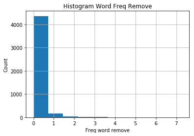

```python
plt.figure()
my_spam['word_freq_remove:'].hist()
plt.title('Histogram Word Freq Remove')
plt.xlabel('Freq word remove')
plt.ylabel('Count')
plt.show()
```

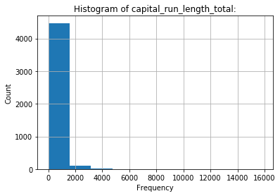

```python
plt.figure()
my_spam['capital_run_length_total:'].hist()
plt.title('Histogram of capital_run_length_total:')
plt.xlabel('Frequency')
plt.ylabel('Count')
plt.show()
```

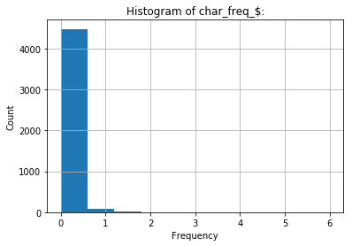

```python
plt.figure()
my_spam['char_freq_$:'].hist()
plt.title('Histogram of char_freq_$:')
plt.xlabel('Frequency')
plt.ylabel('Count')
plt.show()
```

```
array([[<matplotlib.axes._subplots.AxesSubplot object at 0x000000A3559BDDA0>,
      dtype=object)
```

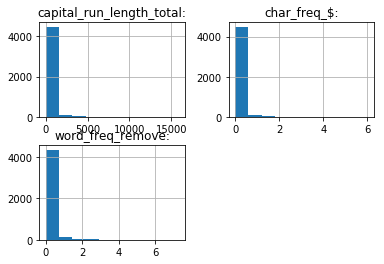

```python
X.hist() # or do it all at once.
```

## Question 2

K - Nearest Neighbor Classifier Logistic Regression (with and without regularization) Support Vector Machine Classifier Decision Trees Ensemble Trees (e.g. Bagging, Random Forests, Boosted Trees)

## Question 3

Splitting into training and testing sets ensure two sets are homogeneous such that each case has probability being contained in each set. The training set is used to train the model. The test set provides an objective measure of new data used to test the models predictive error.

## Question 4

K fold CV utilizes each data point k times. Comparing to simple CV (i.e. splitting into training and testing sets), this is a more reliable metric to use to evaluate model performance because we extract multiple evaluations of prediction error and aggregate them. It is also a more efficient use of our sample to evaluate our model since data are used multiple times.

## Question 5

There are a number of variations on the K-fold cross validation procedure. The splitting of data into folds may be governed by criteria such as ensuring that each fold has the same proportion of observations with a given categorical value, such as the class outcome value. This is called stratified cross-validation (Jason Brownee, 2018).

In stratified k-fold cross-validation, the folds are selected so that the mean response value is approximately equal in all the folds. In the case of binary classification, this means that each fold contains roughly the same proportions of the two types of class labels.

## Queston 6-9

I used logistic regression, random forest, knn, and single decision tree

```python
## Scaling data
from sklearn.preprocessing import StandardScaler
Xss = StandardScaler()
X_s = Xss.fit_transform(X)
X_s = pd.DataFrame(X_s,columns=X.columns)
y = my_spam.spam
y_s = y.values.reshape((-1,1))

## Splitting scaled dataset
X_train_s, X_test_s, y_train_s, y_test_s = train_test_split(X_s, y_s, random_state=42)

# Logistic regression

import statsmodels.api as sm
import pylab as pl
from sklearn.linear_model import LogisticRegression

## Fitting on unscaled dataset
lr = LogisticRegression(C=1e9)
lr.fit(X_train, y_train)
y_pred = lr.predict(X_test) # y_pred includes your predictions

#Evaluating prediction error on test data directly -- using 'accuracy' as scoring argument as it is better suited to predictive models
print("accuracy: {:.5f}".format(lr.score(X_test, y_test)))

#Cross validation accuracy
print(np.mean(cross_val_score(lr, X_train, y_train,scoring='accuracy', cv=5)))
```

```
accuracy: 0.84883
0.8643501140047265
```

```python
#Import Random Forest Model
from sklearn.ensemble import RandomForestClassifier
#Create a Gaussian Classifier
clf=RandomForestClassifier(n_estimators=100, random_state = 0)
#Train the model using the training sets y_pred=clf.predict(X_test)
clf.fit(X_train,y_train)
y_pred=clf.predict(X_test)
#Import scikit-learn metrics module for accuracy calculation
from sklearn import metrics
# Model Accuracy, how often is the classifier correct?
#print("Accuracy on Test Data:",metrics.accuracy_score(y_test, y_pred))
import numpy as np
from sklearn.cross_validation import cross_val_score

model = clf
print("Random Forest Classifier's cross validation accuracy:", np.mean(cross_val_score(model, X_train, y_train, cv=10)))
print("Random Forest Classifier's Test-Data prediction accuracy: {:.5f}".format(model.score(X_test, y_test)))
```

```
Random Forest Classifier's cross validation accuracy: 0.9110022725900123
Random Forest Classifier's Test-Data prediction accuracy: 0.90617
```

```python
from sklearn.neighbors import KNeighborsClassifier
from sklearn.model_selection import GridSearchCV

knn_param = {'n_neighbors': np.arange(2, 20, 1)}
knnGrid = GridSearchCV(KNeighborsClassifier(), knn_param, cv=10)
knnGrid.fit(X_train, y_train)

print("Best parameters: {}".format(knnGrid.best_params_))
print("Best mean cross-validation score: {:.3f}".format(knnGrid.best_score_))

print("Train score: " + str(knnGrid.score(X_train, y_train)))
print("Test score: " + str(knnGrid.score(X_test, y_test)))
```

```
Best parameters: {'n_neighbors': 3}
Best mean cross-validation score: 0.734
Train score: 0.8469565217391304
Test score: 0.7454387489139879
```

```python
# Decision Tree
from sklearn.tree import DecisionTreeClassifier
tree = DecisionTreeClassifier()
model = tree.fit(X_train,y_train)

print("Training set score: {:.4f}".format(model.score(X_train, y_train)))
print("Testing set score: {:.4f}".format(model.score(X_test, y_test)))

print("Cross Validation: ",np.mean(cross_val_score(model, X_train, y_train,scoring='accuracy', cv=10)))
```

```
Training set score: 0.9241
Testing set score: 0.8141
Cross Validation:  0.834776734834626
```

## Question 10-11

```python
X = my_spam.loc[:, ["word_freq_remove:", "capital_run_length_total:", "char_freq_$:",
                    "char_freq_!:", "capital_run_length_longest:", "word_freq_your:"]]
X.head(6)
y = array[:,57]
X_train, X_test, y_train, y_test = train_test_split(X, y, random_state=0)
```

```python
## Scaling data
from sklearn.preprocessing import StandardScaler
Xss = StandardScaler()
X_s = Xss.fit_transform(X)
X_s = pd.DataFrame(X_s,columns=X.columns)
y = my_spam.spam
y_s = y.values.reshape((-1,1))

## Splitting scaled dataset
X_train_s, X_test_s, y_train_s, y_test_s = train_test_split(X_s, y_s, random_state=42)

# Logistic regression

import statsmodels.api as sm
import pylab as pl
from sklearn.linear_model import LogisticRegression

## Fitting on unscaled dataset
lr = LogisticRegression(C=1e9)
lr.fit(X_train, y_train)
y_pred = lr.predict(X_test) # y_pred includes your predictions

#Evaluating prediction error on test data directly -- using 'accuracy' as scoring argument as it is better suited to predictive models
print("accuracy: {:.5f}".format(lr.score(X_test, y_test)))
```

[output not shown]

```python
#Import Random Forest Model
from sklearn.ensemble import RandomForestClassifier
#Create a Gaussian Classifier
clf=RandomForestClassifier(n_estimators=100, random_state = 0)
#Train the model using the training sets y_pred=clf.predict(X_test)
clf.fit(X_train,y_train)
y_pred=clf.predict(X_test)
#Import scikit-learn metrics module for accuracy calculation
from sklearn import metrics
# Model Accuracy, how often is the classifier correct?
#print("Accuracy on Test Data:",metrics.accuracy_score(y_test, y_pred))
import numpy as np
from sklearn.cross_validation import cross_val_score

model = clf
print("Random Forest Classifier's cross validation accuracy:", np.mean(cross_val_score(model, X_train, y_train, cv=10)))
print("Random Forest Classifier's Test-Data prediction accuracy: {:.5f}".format(model.score(X_test, y_test)))
```

[output not shown]

```python
from sklearn.neighbors import KNeighborsClassifier
from sklearn.model_selection import GridSearchCV

knn_param = {'n_neighbors': np.arange(2, 20, 1)}
knnGrid = GridSearchCV(KNeighborsClassifier(), knn_param, cv=10)
knnGrid.fit(X_train, y_train)

print("Best parameters: {}".format(knnGrid.best_params_))
print("Best mean cross-validation score: {:.3f}".format(knnGrid.best_score_))

print("Train score: " + str(knnGrid.score(X_train, y_train)))
print("Test score: " + str(knnGrid.score(X_test, y_test)))
```

```
Best parameters: {'n_neighbors': 3}
Best mean cross-validation score: 0.772
Train score: 0.875072463768116
Test score: 0.7758470894874022
```

```python
# Decision Tree
from sklearn.tree import DecisionTreeClassifier
tree = DecisionTreeClassifier()
model = tree.fit(X_train,y_train)

print("Training set score: {:.4f}".format(model.score(X_train, y_train)))
print("Testing set score: {:.4f}".format(model.score(X_test, y_test)))

print("Cross Validation: ",np.mean(cross_val_score(model, X_train, y_train,scoring='accuracy', cv=10)))
```

```
Training set score: 0.9968
Testing set score: 0.8714
Cross Validation:  0.8805673487359023
```

## Question 14: What variable that currently is not in your model, if included, would be likely to increase your final model's predictive power?

This is an open-ended question. Basically any variable could be potentially helpful. You can justify your answer by: A. check it by observing how the feature changes for values of the DV (e.g.-could compare two boxplots) B. check variable importance using Random forest; C. argue using description file;

## Question 15: Lastly, you have listed each of the models that make since for predicting dependent variables like spam. List each model we have focused on in class thus far that you could use to evaluate data with a continuous dependent variable.

Since the dependent variable (i.e. y , response variable) is continuous, this is a regression problem. For regression problems, you will be able to apply any regression methods. Here we have learned linear regression, penalized regression (LASSO and RIDGE), decision trees for regression, Ensemble trees for regression, knn for regression (and we will finish the course learning neural networks, which can be used for classification and regression problems).